# Noções Básicas de R - Aula 1

# Exemplo de uso de R + Markdown + knitr

Prof. Dr. Cleuler Barbosa das Neves  
[currículo.lattes](http://buscatextual.cnpq.br/buscatextual/visualizacv.do?id=K4786159E2)

AULA N. 02 - REVISÃO E RESOLUAÇÃO DE EXERCÍCIOS

# Com a perna no Mundo…As funções… e seus pacotes!

# [================================================]

# [A 1ª faz CRAN! A 2ª faz CRAN! E CRAN, CRAN, CRAN!!!

# [================================================]

```r
#[=========================================================================]
#[                   Pacotes do System Library                             ]
#[=========================================================================]

#Pacotes de importação de BD
#para ativar um pacote do System Library (vem c/a instalação do R): 2.000 f's
library(foreign) # argumento não precisa das aspas
# Para carregar Base de Dados dos aplicativos:
# Minitab, S, SAS, SPSS, Stata, Systat, Weka, dBase ...

#[=========================================================================]
#[                    Pacotes da User Library                              ]
#[=========================================================================]

#P/instalar um pacote da web (CRAN) basta executar install.packages() 1 vez
#install.packages("data.table") # Para carregar BD's de grandes dimensões
library(data.table) # (p.53-53 do livro R_CS); argumento não precisa das aspas
# 1- converter o arquivo para .csv usando a função fwf2csv () do pacote descr
# 2- carregar o BD com a função fread() do pacote data.table, que usa menos
#    memória que a função read.fwf() do pacote ...
#install.packages("sqldf") # p/carregar partes de BD's de grandes dimensões
library(sqldf) # R_SC: (p. 53-54)
#install.packages("descr")#Um pacote tem de ser instalado 1 vez no seu micro
library(descr) # Ativado o pacote, suas funções são disponibilizadas p/uso
# "descr" é um pacote com funções voltadas para Estatística Descritiva

#install.packages("gdata")
library(gdata) # pacote para manipulação de dados (BD's) (p. 45)
```

```r
               # No Windows poderá ser necessário instalar ActivePerl
               # ou outro interpretador da linguagem perl.

#install.packages("igraph") # Océu é o limite!!!!!!!!!!!!!!!!!!!!!!!!!!!!!!
library(igraph) # pacote para Network Analysis and Visualization
                # R_CS: cap. 12- Análise de Redes Sociais (com grafos)

#install.packages("knitr")
library(knitr) # pacote para geração de Relatório Dinâmico em R (p. 119)

#install.packages("memisc") # para surveys
library(memisc) # pacote para manipulação de pesquisa de dados (p. 66, 89)
                # e para apresentação de análises de seus resultados

#install.packages("rgdal") # para exibição de Mapas e dados espacializados
library(rgdal) # R_SC: cap. 11- Mapas (p. 134-139)
# Requer a instalação do pacote sp
#install.packages("sp")
library(sp)

#install.packages("rmarkdown") # para instalação do RMarkdown
library(rmarkdown) #R_SC: geração Relatórios Dinâmicos no RStudio(p. 115-19)
# Requer instalação de outros pacotes p/rodar o RMarkdown dentro do RStudio
#install.packages("htmltools") - esse não precisou, veio c/o RMarkdown
library(htmltools) # Ferramentas para HTML
#install.packages("caTools")#   - esse precisou e instalou o bitops
library(caTools)#Tools: moving windows statistics, GIF, Base64, ROC AUC etc.

#install.packages(c("bindr", "bindrcpp", "Rcpp", "stringi"))
library(bindr)# library deve ter package com comprimento 1
library(bindrcpp)#
library(Rcpp)#
library(stringi)#
#install.packages(c("cluster", "Matrix"), lib="C:/Users/cleuler-bn/Documents/R/R-3.4.4/library")
library(cluster)#
library(Matrix)#

#install.packages(c("financial", "FinancialInstrument", "FinancialMath"))
library(financial)#
library(FinancialInstrument)#
library(FinancialMath)#
#install.packages("tinytex")#   - foi preciso instalar para gerar arquivo .pdf direto do RMarkdown
#library(tinytex)# para carregar o pacote tinytex, que gera arquivo .tex e certamente converte para .pdf
#                  Mas isso gerou uma v2.pdf no formato de uma janela do PDF, sem os marcadores do lado esquerdo!!!!!
#                  Do Jeito antigo estava melhor e gravava um .pdf na pasta R_CS/Aula1 que ao abrir no Adobe
#                  apresentou na parte esquerda da tela do Adobe todos os marcadores das secções do arquivo (melhor)!
#[=========================================================================]
#[                                                                         ]
#[=========================================================================]
```

# rEVISÃO - Acessando e definindo funções

## Função function()

A função `function()` é uma das principais funções do R;  
Ela traz em si a base em que a própria Linguagem R encontra-se entruturada. Uma função, uma vez definida, pode receber argumentos e pode retornar resultados ou valores através da função return(value). Principais *argumentos* da função: arglist.

Exemplo de definição e uso de uma função.  
Q1) Como elaborar uma função em R para obter o resultado da série: somatório x${_{i}}$, para i = 1 à n, n inteiro diferente de zero.

${\displaystyle \sum _{i=1}^{n}x_{i}=x_{1}+x_{2}+\cdots +x_{n}}$

Resposta

```r
somatoria <- function(x){
  n<-length(x)
  s<-0
  for (i in 1:n) {
    s<-s+x[i]
  }
  s
}

# Invocando a função somatória para uma <var> <vector> <num>
a<-1
somatoria(a)
```

```
## [1] 1
```

```r
a<-c(1,2,3)
y<-somatoria(a)
a<-c(1:4)
somatoria(a)
```

```
## [1] 10
```

```r
a<-c(1:1000)
somatoria(a)
```

```
## [1] 500500
```

```r
sum(a)
```

```
## [1] 500500
```

```r
args(sum)
```

```
## function (..., na.rm = FALSE)
## NULL
```

```r
a[1001]<-NA
a
```

```
##    [1]    1    2    3    4    5    6    7    8    9   10   11   12   13
##   [14]   14   15   16   17   18   19   20   21   22   23   24   25   26
##   [27]   27   28   29   30   31   32   33   34   35   36   37   38   39
##   [40]   40   41   42   43   44   45   46   47   48   49   50   51   52
##   [53]   53   54   55   56   57   58   59   60   61   62   63   64   65
##   [66]   66   67   68   69   70   71   72   73   74   75   76   77   78
##   [79]   79   80   81   82   83   84   85   86   87   88   89   90   91
##   [92]   92   93   94   95   96   97   98   99  100  101  102  103  104
##  [105]  105  106  107  108  109  110  111  112  113  114  115  116  117
##  [118]  118  119  120  121  122  123  124  125  126  127  128  129  130
##  [131]  131  132  133  134  135  136  137  138  139  140  141  142  143
##  [144]  144  145  146  147  148  149  150  151  152  153  154  155  156
##  [157]  157  158  159  160  161  162  163  164  165  166  167  168  169
##  [170]  170  171  172  173  174  175  176  177  178  179  180  181  182
##  [183]  183  184  185  186  187  188  189  190  191  192  193  194  195
```

[output cut: 62 more lines]

```r
somatoria(a)
```

```
## [1] NA
```

```r
sum(a)
```

```
## [1] NA
```

```r
sum(a, na.rm = TRUE) # 1 NA será removido para não indeterminar a soma de 1000 parcelas
```

```
## [1] 500500
```

```r
mean(a, na.rm = TRUE)# nem sua média
```

```
## [1] 500.5
```

```r
sd(a)
```

```
## [1] NA
```

```r
sd(a, na.rm = TRUE)  # nem seu desvio padrão (standart desviation)
```

```
## [1] 288.8194
```

```r
####################################################################################################################
# CUIDADO PORQUE UM ÚNICO NA NUMA BD PROPAGA SUA CAPACIDADE DE IMPEDIR QUE CÁLCULOS DE ESTATÍSTICA SEJAM PROCESSADOS
####################################################################################################################
```

# help - PEDINDO SOCORRO: ao próprio R e à web

```r
help() # por ?
```

```
## starting httpd help server ... done
```

```r
help.start()
```

```
## If nothing happens, you should open
## 'http://127.0.0.1:23449/doc/html/index.html' yourself
```

```r
args(setwd)
```

```
## function (dir)
## NULL
```

```r
help(demo)
?q
args(apropos)
```

```
## function (what, where = FALSE, ignore.case = TRUE, mode = "any")
## NULL
```

```r
?apropos
apropos("csv") # Qual o tipo do seu arg? É diferente do argumento de args?
```

```
##  [1] "fwf2csv"        "getSymbols.csv" "read.csv"       "read.csv.sql"
##  [5] "read.csv.zoo"   "read.csv2"      "read.csv2.sql"  "read.csv2.zoo"
##  [9] "write.csv"      "write.csv2"     "xls2csv"
```

```r
args(help.search)
```

```
## function (pattern, fields = c("alias", "concept", "title"), apropos,
##     keyword, whatis, ignore.case = TRUE, package = NULL, lib.loc = NULL,
##     help.db = getOption("help.db"), verbose = getOption("verbose"),
##     rebuild = FALSE, agrep = NULL, use_UTF8 = FALSE, types = getOption("help.search.types"))
## NULL
```

```r
?help.search
#help.search("install") # Não quis funcionar!!!
??install.packages
??network
#RSiteSearch("social network analysis") # Não quis funcionar!!!
example("ls") # O que significa a abreviatura ls? # Não quis funcionar!!!
```

```
##
## ls> .Ob <- 1
##
## ls> ls(pattern = "O")
## character(0)
##
## ls> ls(pattern= "O", all.names = TRUE)    # also shows ".[foo]"
## [1] ".Ob"
##
## ls> # shows an empty list because inside myfunc no variables are defined
## ls> myfunc <- function() {ls()}
##
## ls> myfunc()
## character(0)
##
## ls> # define a local variable inside myfunc
## ls> myfunc <- function() {y <- 1; ls()}
##
## ls> myfunc()                # shows "y"
## [1] "y"
```

```r
??demo
#demo("graphics")# Não quis funcionar!!!
```

# Exercícios - Resolução em Sala

Refletir e responder às seguintes questões *pragmáticas*:  
1) Olhando para o código (*script*) da função somatoria quais regras sintáticas (estruturais) pode-se extrair do uso dos parenteses, chaves e colchetes na Linguagem R?

parenteses: delimitam o início e o fim de um conjunto de parâmetros, separados por vírgula, de uma função. chaves : delimitam o início e o fim de um conjunto de comandos; o final de um comando demarca o início de outro; para uma melhor documentação e leitura do código do script, separamos as linhas de comando com . linhas de comando não são separadas por vírgula; a execução ou aplicação de uma função para um dado parâmetro é uma linha de comando; a definição de uma função dá-se pela execução da função denominada: function(). um dos principais comando do R é o de atribuição: <- sua aplicação difere muito do conhecido resultado que o símbolo de igual “=” produz na Álgebra. colchetes: delimitam o início e o fim dos index de um vetor, uma matris ou um data.frame qualquer.

R-1: Argumentos virão entre parenteses, separados por vírgula; quando à esquerda do sinal de = ser-lhe-á atribuído o valor à direita. R-2 …

2. Idem para a vírgula e o símbolo de =?
3. Diferencie: funções, objetos, comandos, símbolos e operadores da Linguagem R. Exemplifique.
4. A expressão =!===? é uma *wff* (*well formuled formula*)? Ela faz sentido em Linguagem R? Ou nalguma outra?
5. Se faz, qual o *significado* desse conjunto de *significantes*? Se não, qual rearranjo desses *símbolos* seria capaz de conferir-lhe algum *sentido*? Quiçá aquele que teria implicitamente desejado?
6. Olhando para o mesmo *script* da função somatoria extraia e formule outras regras sintáticas que estruturam o uso da Linguagem R.

R-2: À variável indicada à esquerda do comando de atribuição, cujo símbolo é “<-”“, quando executada a respectiva linha de comando, o R associará uma posição da memória de trabalho com o valor que resultar da expressão situada à direita do mesmo comando.

R-3: o símbolo de dois pontos serve para gerar uma sequencia numérica inteira iniciada pelo valor à sua esquerda e terminada pelo valor a sua direita.

7. Elabore um código para a função identidade na reta. Gere um gráfico para essa função no intervalo [0,5].

```r
id <- function(x) # Início da definição da função identidade
{
  if (is.double(x)|is.integer(x)) { y<-x } else {cat(y<-"Parâmetro repassado não é uma variável real\n")}
  y
} #################  Final da definição da função identidade, que retorna o valor de y=x, se x é um vetor ou matriz real

# Invocando a função identidade para uma <var> <vector> <num>
a<-1
id(a)
```

```
## [1] 1
```

```r
a<-c(1,2,3)
id(a)
```

```
## [1] 1 2 3
```

```r
a<-c(1:4)
id(a)
```

```
## [1] 1 2 3 4
```

```r
a<-c(1:1000)
id(a)
```

```
##    [1]    1    2    3    4    5    6    7    8    9   10   11   12   13
##   [14]   14   15   16   17   18   19   20   21   22   23   24   25   26
##   [27]   27   28   29   30   31   32   33   34   35   36   37   38   39
##   [40]   40   41   42   43   44   45   46   47   48   49   50   51   52
##   [53]   53   54   55   56   57   58   59   60   61   62   63   64   65
##   [66]   66   67   68   69   70   71   72   73   74   75   76   77   78
##   [79]   79   80   81   82   83   84   85   86   87   88   89   90   91
##   [92]   92   93   94   95   96   97   98   99  100  101  102  103  104
##  [105]  105  106  107  108  109  110  111  112  113  114  115  116  117
##  [118]  118  119  120  121  122  123  124  125  126  127  128  129  130
##  [131]  131  132  133  134  135  136  137  138  139  140  141  142  143
##  [144]  144  145  146  147  148  149  150  151  152  153  154  155  156
##  [157]  157  158  159  160  161  162  163  164  165  166  167  168  169
##  [170]  170  171  172  173  174  175  176  177  178  179  180  181  182
##  [183]  183  184  185  186  187  188  189  190  191  192  193  194  195
```

[output cut: 62 more lines]

```r
x<--1:10
y<-id(x)
#x,y
x
```

```
##  [1] -1  0  1  2  3  4  5  6  7  8  9 10
```

```r
y
```

```
##  [1] -1  0  1  2  3  4  5  6  7  8  9 10
```

```r
print (c(x,y))
```

```
##  [1] -1  0  1  2  3  4  5  6  7  8  9 10 -1  0  1  2  3  4  5  6  7  8  9
## [24] 10
```

```r
####################################################################################################################
# CUIDADO PORQUE UM ÚNICO ERRO DE SINTAXE FAZ COM QUE O COMPILADOR INTERROMPA A EXECUÇÃO DO SRCIPT (CÓDIGO FONTE)  #
####################################################################################################################
```

8. Redija e salve um script para a função linear em **R**. Gere um gráfico para essa função no intervalo [0,5] e salve-o no formato .pdf.

```r
linear <- function(a, b, x) # Início da definição da função linear (reta) num plano cartesiano y = a.x + b
                            # a = parâmetro que indica o coeficiente angular da reta
                            # b = parâmetro que indica o coeficiente linear  da reta
                            # x = parâmetro que indica o conjunto de valores em a função será aplicada
{
  y<- a * x + b
  y
} #################  Final da definição da função linear, que retorna o valor de y=a.x+b, se x é um vetor ou matriz real

# Invocando a função linear para uma <var> <vector> <num>
a<-1
b<-0        # Replica a função identidade
x<-(-1:10)
linear(a,b,x)
```

```
##  [1] -1  0  1  2  3  4  5  6  7  8  9 10
```

```r
a<-1/2
b<-0
x<-c(1,2,3)
linear(a,b,x)
```

```
## [1] 0.5 1.0 1.5
```

```r
a<-1+1/2
b<-0
x<-c(1,2,3)
linear(a,b,x)
```

```
## [1] 1.5 3.0 4.5
```

```r
a<-1/2
b<-2
x<-c(1,2,3,4,5)
linear(a,b,x)
```

```
## [1] 2.5 3.0 3.5 4.0 4.5
```

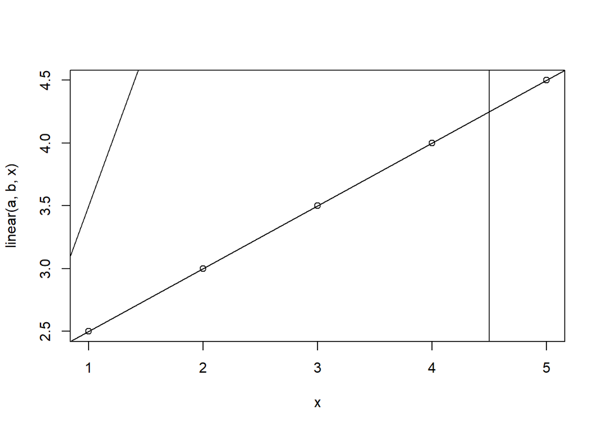

```r
####################################################################################################################
# TENTATIVAS E  ERROS PARA GERAR UM GRÁFICO y=f(x)=a.x + b #
####################################################################################################################

plot(x,linear(a,b,x))
library(graphics)
#plot.new()
abline(b,a,untf = FALSE)
abline(x[1],linear(a,b,x)[1],x[5],linear(a,b,x)[5]) # Não funciona dentro do RMarkdown
```

9. Apresente duas funções lineraes que sejam inversas. Plote-as juntamente com a função identidade.
10. Descrever os tipos de variáveis geradas na Job Area e suas características.

**Trabalho Final do curso:** Na primeira aula registrar a altura declarada e medir e registrar o peso de cada aluno, que poderá identificar-se com um apelido.  
Em cada aula medir e registrar numa BD o peso de cada aluno numa sequencia aleatória.  
Calcular o IMC de cada observação e apontar para os IMC’s acima da faixa recomendada pela literatura médica.  
Calcular a média e o desvio padrão do IMC da população observada; detectar os pontos *outliers*.  
Gerar um série temporal, com período de 7 dias, ao longo dos nossos 10 encontros.  
Tratar eventuais NA’s.  
*Descrever* a variação do IMC médio da turma ao longo do curso, dado que será feito um apelo geral para aqueles acima da média para tentarem reduzi-lo nas próximas 10 semanas.  
Fazer uma regressão linear do IMC médio em função do tempo analisando se ele sofreu alguma variação estatisticamente significativa.  
*Inferir* qual resultado seria alcançado se o curso durasse 20 semanas.

# Objetos

## Vetores

Conjunto de elementos do mesmo tipo (logical, numeric, integer, double character)

1. A forma mais simples de se criar um vetor é usar a função de concatenação `c()`.

```r
value.num  = c(3,4,2,6,20)

value.num
```

```
## [1]  3  4  2  6 20
```

```r
value.char = c("koala", "kangaroo")

value.char
```

```
## [1] "koala"    "kangaroo"
```

```r
value.logical = c(FALSE, FALSE, TRUE, TRUE)

value.logical
```

```
## [1] FALSE FALSE  TRUE  TRUE
```

2. Segunda maneira de criar vetor no R: usando a função `scan`

```r
values = scan(text="
2
3
4
5"
)

values
```

```
## [1] 2 3 4 5
```

3. Outra opção usando comando `rep`

```r
rep(1,5)
```

```
## [1] 1 1 1 1 1
```

```r
rep(c(1,2),3)
```

```
## [1] 1 2 1 2 1 2
```

```r
rep(c(1,6),each=3)
```

```
## [1] 1 1 1 6 6 6
```

```r
rep(c(1,6),c(3,5))
```

```
## [1] 1 1 1 6 6 6 6 6
```

4. Outra opção usando comando `seq`

```r
seq(from=1,to=5)
```

```
## [1] 1 2 3 4 5
```

```r
seq(from=1, to=5, by=0.1)
```

```
##  [1] 1.0 1.1 1.2 1.3 1.4 1.5 1.6 1.7 1.8 1.9 2.0 2.1 2.2 2.3 2.4 2.5 2.6
## [18] 2.7 2.8 2.9 3.0 3.1 3.2 3.3 3.4 3.5 3.6 3.7 3.8 3.9 4.0 4.1 4.2 4.3
## [35] 4.4 4.5 4.6 4.7 4.8 4.9 5.0
```

```r
seq(from=1, to=5, length=10)
```

```
##  [1] 1.000000 1.444444 1.888889 2.333333 2.777778 3.222222 3.666667
##  [8] 4.111111 4.555556 5.000000
```

```r
rep(seq(from=1, to=5, length=10),each=3)
```

```
##  [1] 1.000000 1.000000 1.000000 1.444444 1.444444 1.444444 1.888889
##  [8] 1.888889 1.888889 2.333333 2.333333 2.333333 2.777778 2.777778
## [15] 2.777778 3.222222 3.222222 3.222222 3.666667 3.666667 3.666667
## [22] 4.111111 4.111111 4.111111 4.555556 4.555556 4.555556 5.000000
## [29] 5.000000 5.000000
```

5. Outra opção usando comando `:`

```r
1:5
```

```
## [1] 1 2 3 4 5
```

```r
c(1:5,10)
```

```
## [1]  1  2  3  4  5 10
```

## Operações com Vetores

```r
x = 1:4

y = 5:8

x + y
```

```
## [1]  6  8 10 12
```

```r
2*x +1
```

```
## [1] 3 5 7 9
```

```r
x * y
```

```
## [1]  5 12 21 32
```

```r
x / y
```

```
## [1] 0.2000000 0.3333333 0.4285714 0.5000000
```

```r
log(x)
```

```
## [1] 0.0000000 0.6931472 1.0986123 1.3862944
```

```r
log(x,10)
```

```
## [1] 0.0000000 0.3010300 0.4771213 0.6020600
```

```r
sum(x)
```

```
## [1] 10
```

```r
mean(x)
```

```
## [1] 2.5
```

```r
prod(x)
```

```
## [1] 24
```

```r
var(x)
```

```
## [1] 1.666667
```

## Matriz

Conjunto de elementos dispostos em linhas e colunas, em que todos os elementos são do mesmo tipo

```r
mat.num  = matrix(c(1:16),4,4)

mat.num
```

```
##      [,1] [,2] [,3] [,4]
## [1,]    1    5    9   13
## [2,]    2    6   10   14
## [3,]    3    7   11   15
## [4,]    4    8   12   16
```

```r
mat.char = matrix(LETTERS[1:4],2,2)

mat.char
```

```
##      [,1] [,2]
## [1,] "A"  "C"
## [2,] "B"  "D"
```

# Manipulando Matrizes

```r
#Criando nomes para as linhas de uma matriz

rownames(mat.num) = c("Sao Paulo", "Americana", "Piracicaba", "Madson" )

colnames(mat.num) = 1:4

mat.num
```

```
##            1 2  3  4
## Sao Paulo  1 5  9 13
## Americana  2 6 10 14
## Piracicaba 3 7 11 15
## Madson     4 8 12 16
```

```r
#Multiplicação elemento a elemento

mat.num2 = diag(seq(10,40,by=10))

mat.num2
```

```
##      [,1] [,2] [,3] [,4]
## [1,]   10    0    0    0
## [2,]    0   20    0    0
## [3,]    0    0   30    0
## [4,]    0    0    0   40
```

```r
mat.num3 = mat.num * mat.num2

mat.num3
```

```
##             1   2   3   4
## Sao Paulo  10   0   0   0
## Americana   0 120   0   0
## Piracicaba  0   0 330   0
## Madson      0   0   0 640
```

```r
#Multiplicação de Matrizes

iden = diag(4)

iden
```

```
##      [,1] [,2] [,3] [,4]
## [1,]    1    0    0    0
## [2,]    0    1    0    0
## [3,]    0    0    1    0
## [4,]    0    0    0    1
```

```r
mat.num%*%iden
```

```
##            [,1] [,2] [,3] [,4]
## Sao Paulo     1    5    9   13
## Americana     2    6   10   14
## Piracicaba    3    7   11   15
## Madson        4    8   12   16
```

```r
#Acessando elementos das matrizes

#Um elemento
mat.num[1,1]
```

```
## [1] 1
```

```r
#Linhas
mat.num[1,]
```

```
##  1  2  3  4
##  1  5  9 13
```

```r
#Colunas
mat.num[,3]
```

```
##  Sao Paulo  Americana Piracicaba     Madson
##          9         10         11         12
```

```r
#Sub Matrizes

mat.num[c(1,3,4), c(2,1,4)]
```

```
##            2 1  4
## Sao Paulo  5 1 13
## Piracicaba 7 3 15
## Madson     8 4 16
```

```r
mat.num[c(T,F,T,T), c(T,T,F,T)]
```

```
##            1 2  4
## Sao Paulo  1 5 13
## Piracicaba 3 7 15
## Madson     4 8 16
```

```r
mat.num[-c(1,3,4), -c(2,1,4)]
```

```
## [1] 10
```

# Data.frames

São similares às matrizes no entanto permite que as colunas tenham diferentes tipos

```r
data(iris)

iris
```

```
##     Sepal.Length Sepal.Width Petal.Length Petal.Width    Species
## 1            5.1         3.5          1.4         0.2     setosa
## 2            4.9         3.0          1.4         0.2     setosa
## 3            4.7         3.2          1.3         0.2     setosa
## 4            4.6         3.1          1.5         0.2     setosa
## 5            5.0         3.6          1.4         0.2     setosa
## 6            5.4         3.9          1.7         0.4     setosa
## 7            4.6         3.4          1.4         0.3     setosa
## 8            5.0         3.4          1.5         0.2     setosa
## 9            4.4         2.9          1.4         0.2     setosa
## 10           4.9         3.1          1.5         0.1     setosa
## 11           5.4         3.7          1.5         0.2     setosa
## 12           4.8         3.4          1.6         0.2     setosa
## 13           4.8         3.0          1.4         0.1     setosa
## 14           4.3         3.0          1.1         0.1     setosa
```

[output cut: 136 more lines]

```r
iris$Sepal.Length
```

```
##   [1] 5.1 4.9 4.7 4.6 5.0 5.4 4.6 5.0 4.4 4.9 5.4 4.8 4.8 4.3 5.8 5.7 5.4
##  [18] 5.1 5.7 5.1 5.4 5.1 4.6 5.1 4.8 5.0 5.0 5.2 5.2 4.7 4.8 5.4 5.2 5.5
##  [35] 4.9 5.0 5.5 4.9 4.4 5.1 5.0 4.5 4.4 5.0 5.1 4.8 5.1 4.6 5.3 5.0 7.0
##  [52] 6.4 6.9 5.5 6.5 5.7 6.3 4.9 6.6 5.2 5.0 5.9 6.0 6.1 5.6 6.7 5.6 5.8
##  [69] 6.2 5.6 5.9 6.1 6.3 6.1 6.4 6.6 6.8 6.7 6.0 5.7 5.5 5.5 5.8 6.0 5.4
##  [86] 6.0 6.7 6.3 5.6 5.5 5.5 6.1 5.8 5.0 5.6 5.7 5.7 6.2 5.1 5.7 6.3 5.8
## [103] 7.1 6.3 6.5 7.6 4.9 7.3 6.7 7.2 6.5 6.4 6.8 5.7 5.8 6.4 6.5 7.7 7.7
## [120] 6.0 6.9 5.6 7.7 6.3 6.7 7.2 6.2 6.1 6.4 7.2 7.4 7.9 6.4 6.3 6.1 7.7
## [137] 6.3 6.4 6.0 6.9 6.7 6.9 5.8 6.8 6.7 6.7 6.3 6.5 6.2 5.9
```

```r
iris$Renato = TRUE

iris
```

```
##     Sepal.Length Sepal.Width Petal.Length Petal.Width    Species Renato
## 1            5.1         3.5          1.4         0.2     setosa   TRUE
## 2            4.9         3.0          1.4         0.2     setosa   TRUE
## 3            4.7         3.2          1.3         0.2     setosa   TRUE
## 4            4.6         3.1          1.5         0.2     setosa   TRUE
## 5            5.0         3.6          1.4         0.2     setosa   TRUE
## 6            5.4         3.9          1.7         0.4     setosa   TRUE
## 7            4.6         3.4          1.4         0.3     setosa   TRUE
## 8            5.0         3.4          1.5         0.2     setosa   TRUE
## 9            4.4         2.9          1.4         0.2     setosa   TRUE
## 10           4.9         3.1          1.5         0.1     setosa   TRUE
## 11           5.4         3.7          1.5         0.2     setosa   TRUE
## 12           4.8         3.4          1.6         0.2     setosa   TRUE
## 13           4.8         3.0          1.4         0.1     setosa   TRUE
## 14           4.3         3.0          1.1         0.1     setosa   TRUE
```

[output cut: 136 more lines]

# List

Generalização dos vetores no sentido de que uma lista é uma coleção de objetos

```r
dados<-c(rep(1:4, 2, each = 2))
A = list(x = 1:4, y = matrix(1:4,2,2), w = dados, v = list(B=4,C=5))

A
```

```
## $x
## [1] 1 2 3 4
##
## $y
##      [,1] [,2]
## [1,]    1    3
## [2,]    2    4
##
## $w
##  [1] 1 1 2 2 3 3 4 4 1 1 2 2 3 3 4 4
##
## $v
## $v$B
## [1] 4
##
## $v$C
## [1] 5
```

```r
A[[1]]
```

```
## [1] 1 2 3 4
```

```r
A[[4]]
```

```
## $B
## [1] 4
##
## $C
## [1] 5
```

```r
A$x
```

```
## [1] 1 2 3 4
```

```r
A$y
```

```
##      [,1] [,2]
## [1,]    1    3
## [2,]    2    4
```

```r
A$w
```

```
##  [1] 1 1 2 2 3 3 4 4 1 1 2 2 3 3 4 4
```

```r
A$v
```

```
## $B
## [1] 4
##
## $C
## [1] 5
```

```r
B = list(s = 1:5, r = 2)

Q = c(A,B)

Q
```

```
## $x
## [1] 1 2 3 4
##
## $y
##      [,1] [,2]
## [1,]    1    3
## [2,]    2    4
##
## $w
##  [1] 1 1 2 2 3 3 4 4 1 1 2 2 3 3 4 4
##
## $v
## $v$B
## [1] 4
##
## $v$C
## [1] 5
##
##
## $s
## [1] 1 2 3 4 5
##
## $r
## [1] 2
```